# Visualisation TP-1 : “ggplot2”

rchailan

Novembre 2018

### Introduction

Dans ce TP-1 d’introduction à l’utilisation de `ggplot2`, vous allez manipuler différents éléments géométriques `geom_xxx` et autres couches graphiques de `ggplot2` à travers l’utilisation de plusieurs jeux de données.

L’exploration et la personnalisation des graphes sont infinies; nous n’avons pas la prétention de découvrir cet univers en 1h30 de TP.  
Toutefois, en le terminant, vous aurez acquis les bases essentielles pour réaliser des visualisations claires et efficaces sous `R` à l’aide de `ggplot2`.

### Exercice 1 : (scatter plot / nuage de points)

Le premier exercice consiste à réaliser un nuage de points. Additionnellement, vous allez devoir ajuster un modèle linéaire sur chaque *sous-groupe* des données de la base [`iris`](https://archive.ics.uci.edu/ml/datasets/iris) que vous devez déjà connaitre. Le graphe ci-après est un exemple de ce qui est attendu comme résultat.

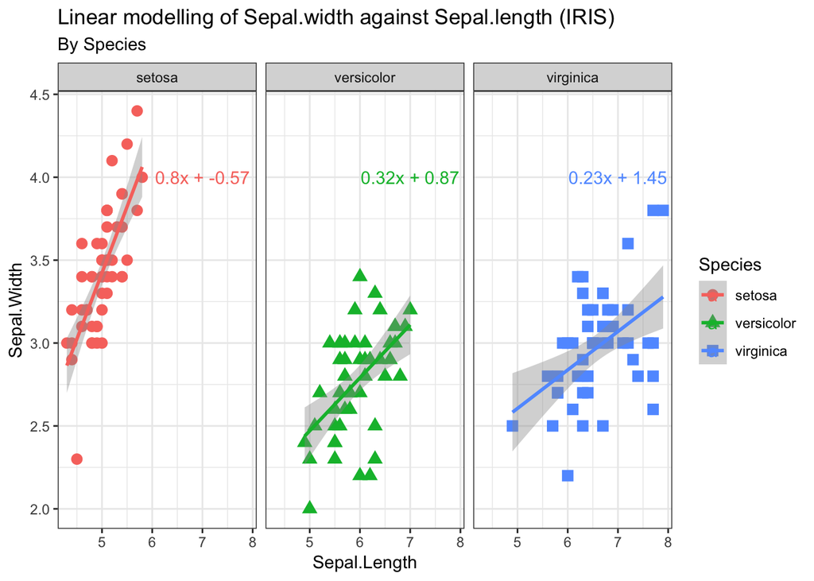

1. Tout d’abord, commencez à charger la librairie `ggplot2` dans votre environnement.

```r
# load library
library(ggplot2)
```

2. La base de données `iris` est chargée par défaut dans **R**. Affichez le début du tableau pour visualiser ses composants. Combien d’espèces sont représentées dans ce jeu de données ? Combien de variables quantitatives sont présentes ?
3. Construisez le nuage de points représentant la `Sepal.width` en fonction de la `Sepal.length` à l’aide de `geom_point()`. *Rappel : il suffit de saisir `?mafonction` pour obtenir l’aide de la fonction `mafonction`*.

```r
# plot construction
ggplot(data = iris, ...) +
  geom_point(...)
```

4. Donnez une couleur aux points respective à l’espèce représentée. Idem pour la forme des points.
5. Utilisez `facet_grid()` pour regrouper les points par espèce.
6. Rajoutez un thème ainsi qu’un titre.
7. Utilisez `stat_smooth(method = ...)` pour ajuster un modèle linéaire aux points *– un modèle par groupe d’espèce*. Que représente la zone grisée ?
8. *[facultatif]* Il est toujours intéressant d’afficher les valeurs des paramètres des modèles linéaires qui ont été ajustés. Pour que ce soit plus simples et puisque le modèle linéaire un rapide, nous ajustons dans un premier temps un modèle linéaire par espèce en dehors de la fonction de visualisation. L’idée est de récupérer les paramètres de ces modèles pour les afficher sur le graphe final à l’aide de `geom_text()`.

```r
# fit lm
coef <- lm(Sepal.Width ~ Sepal.Length:Species + Species - 1, data=iris)$coefficients
# plot construction
ggplot(...) +
  geom_point(..) +
  ... -> p
# get annotation text
ann_text <- data.frame(Sepal.Length = 7, Sepal.Width = 4,
                       intercept = coef[1:3],
                       a = coef[4:6],
                       Species = c('setosa', 'versicolor', 'virginica'))

p <- p + geom_text(data = ann_text, label = ...)
# print plot
print(p)
```

### Exercice 2 : (histogram / histogramme)

Dans cet exercice vous allez construire un histogramme (voir figure ci-après) à partir du jeu de données `weight` qui recense le poids de $n$ individus par genre. Vous pourrez également tracer la distribution empirique de ces données.

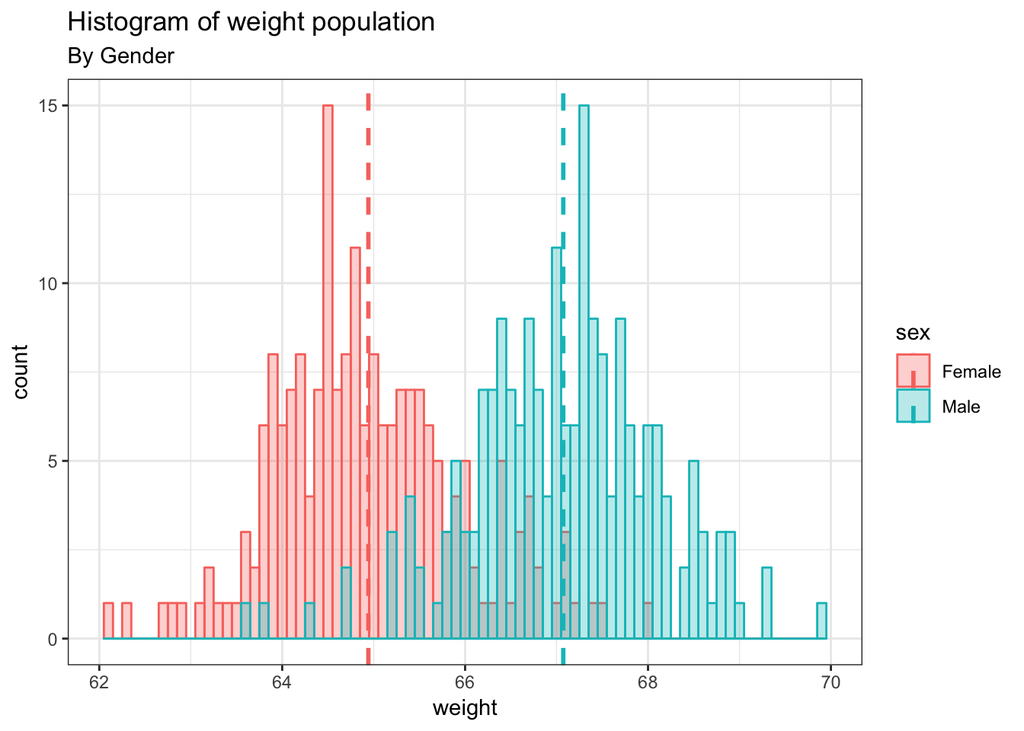

1. Le jeu de données `weight` se trouve dans le package `easyGgplot2`. Pour l’installer, saisir la commande suivante. *Note : si vous ne disposez pas du package `devtools`, pensez à l’installer au préalable*.

```r
# install package (from github) to retrieve data
# first you need to install devtools if not available
devtools::install_github("easyGgplot2", "kassambara")
```

2. Chargez ensuite la librairie et visualisez le dataset. Quelle fonction pouvez vous utilisez pour avoir un rapide résumé statistique de ce tableau ? Combien vaut le nombre d’individus $n$? Quelle est la répartition par genre ?

```r
# load library
library(easyGgplot2)
# have a look on the `weight` dataframe
head(weight)
```

3. Construire l’histogramme des poids par genre. La couleur et le remplissage de l’histogramme doivent être fonction du genre.

```r
# construct histogram plot
ggplot(...) +
  geom_histogram(...)
```

4. Ajoutez un titre et un thème à votre graphique.
5. Calculez la moyenne du poids par genre et l’affichez sous forme de ligne verticale à l’aide de `geom_vline()`. La couleur des lignes verticales doit être équivalente à celle du genre représenté dans l’histogramme initial.

```r
# load dplyr to use `%>%`, `group_by` and `summarise` functions
library(dplyr, quietly = TRUE)
# compute mean by group
cmean <- weight %>% group_by(sex) %>% summarise(mean = mean(weight))

# construct histogram plot
ggplot(...) +
  geom_histogram(...) +
  geom_vline(data = cmean, ...) +
  ...
```

6. En utilisant `geom_density()` et en ne changeant qu’une ligne de code à votre construction de graphe, visualisez la répartition du poids en fonction du genre grâce à la distribution empirique des données (voir figure ci-après).

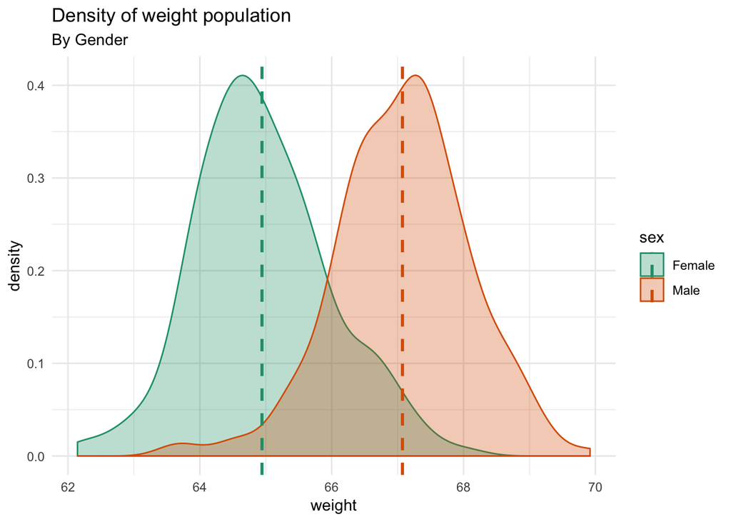

7. *[facultatif]* Faites évoluer votre graphe en changeant de theme, mais aussi de couleur à l’aide des échelles de couleurs `scale_color_brewer()` et `scale_fill_brewer()` par exemple.

### Exercice 3 : (boxplot / boîte à moustache)

Ce troisième exercice vous invite à travailler sur la représentation des données par les boîtes à moustache; soit un résumé statistique de leur distribution. Nous allons utiliser le jeu de données `Glass` du package `mlbench` pour tester cette représentation graphique. La figure ci-après en est une illustration.

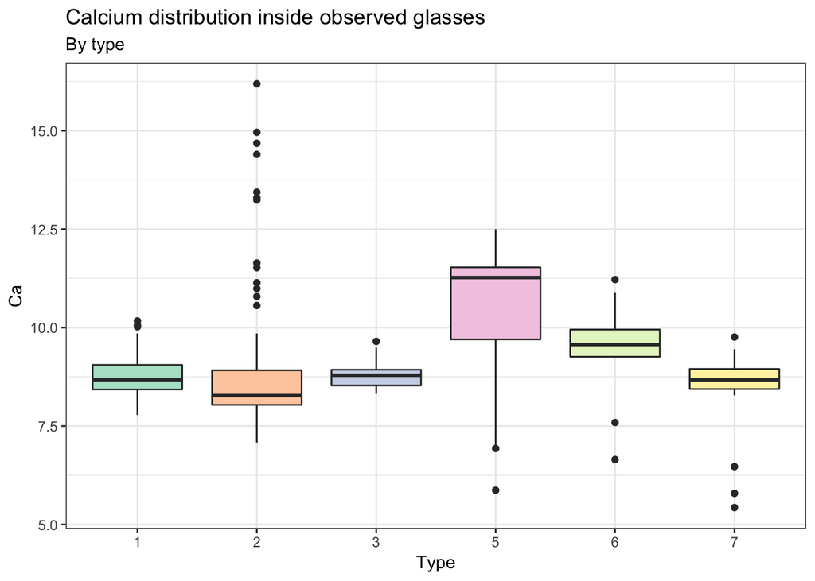

1. Installez le package `mlbench` puis charger le jeu de données `Glass`.

```r
# install package
install.packages('mlbench')
# load package 'mlbench' to get `Glass` dataset
library(mlbench)
data(Glass)
```

2. À l’aide de `geom_boxplot()`, construisez les boxplots de la répartition du *Calcium* observé dans les verres analysés, en fonction de leur *type*.

```r
# build a first plot
ggplot(data = Glass, ...) +
  geom_boxplot(...)
```

3. Utilisez un thème, un jeu de couleur non standard et rajoutez un titre à votre graphe.
4. À l’aide d’une couche de type `facet_xxx`, affichez dans un même graphe les boxplots *– toujours en fonction du type de verre –* des éléments chimiques suivants : Potassium, Calcium, Baryum et Fer. Vous aurez besoin dans un premier temps de transformer le jeu de données initial afin de pouvoir facilement construire le graphe. Nous utilisons ici la fonction `reshape2::melt`.

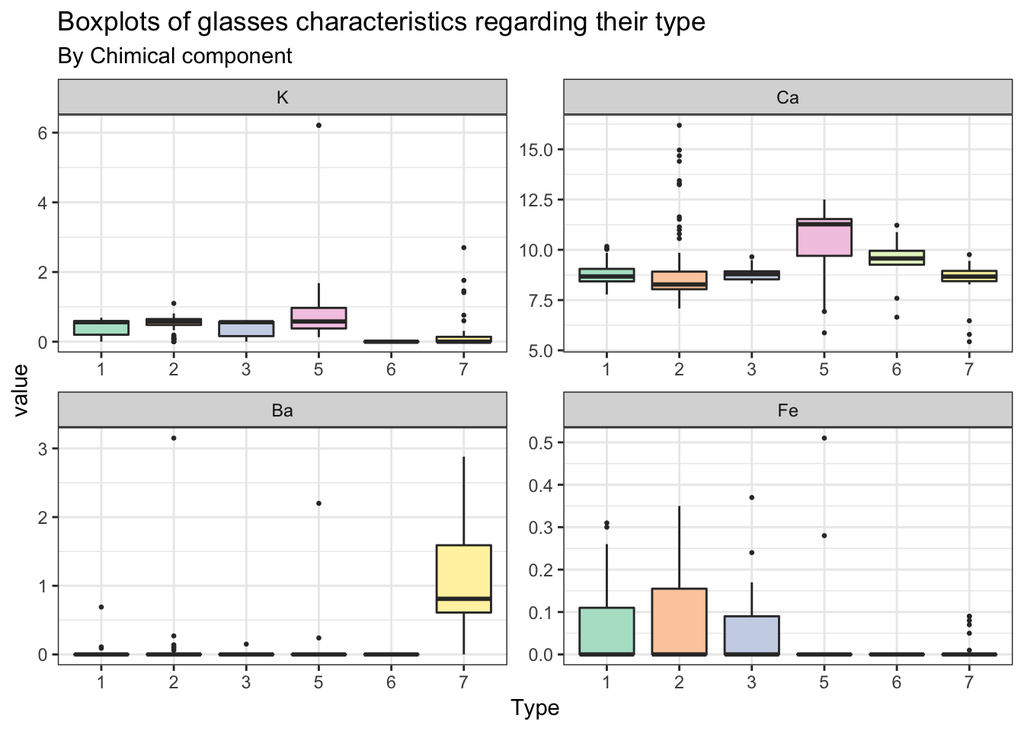

```r
# reshape dataset
Glass.reshaped <- reshape2::melt(Glass[,6:10], id.vars="Type")
head(Glass.reshaped)

# build second plot
ggplot(data = Glass.reshaped, ...) +
  geom_boxplot(...) +
  facet_wrap(...) +
  ...
```

5. Pensez à changer la contrainte sur les échelles de la fonction `facet_xxx` pour que votre graphe soit le plus lisible possible.

### Exercice 4 : (time series / séries chronologiques)

En science des données, les séries chronologiques sont des objets mathématiques récurrents. Une bonne illustration d’une série chronologique est l’évolution du cours d’un symbole boursier. Vous allez dans cet exercice afficher la croissance (en pourcentage) du cours de cinq symboles côtés en bourse.

1. La première étape est de récupérer le jeu de données depuis internet. Pour gagner du temps *– et comme ce code dépasse le cadre de ce cours –* vous pouvez saisir le code ci-après. Il a pour objectif de récupérer l’évolution (quotidienne) du cours des symboles de grandes entreprises d’informatique. Nous récupérons ici deux ans de données.

```r
# libraries to load
library(quantmod, quietly = TRUE)
library(tibble, quietly = TRUE)
library(dplyr, quietly = TRUE)
library(lubridate, quietly = TRUE)
library(tidyr, quietly = TRUE)

# get symbols and gather the data into one dataset
google <- tibble::rownames_to_column(data.frame(getSymbols("GOOG", auto.assign = FALSE)))
facebook <- tibble::rownames_to_column(data.frame(getSymbols("FB", auto.assign = FALSE)))
twitter <- tibble::rownames_to_column(data.frame(getSymbols("TWTR", auto.assign = FALSE)))
amazon <- tibble::rownames_to_column(data.frame(getSymbols("AMZN", auto.assign = FALSE)))
apple <- tibble::rownames_to_column(data.frame(getSymbols("AAPL", auto.assign = FALSE)))
df_ts <- bind_rows(google, facebook, amazon, apple, twitter)

# prepare the dataframe to be plotted
df_ts <- df_ts %>% tidyr::gather(measure, value, -rowname, na.rm=TRUE) %>%
  separate(measure, into=c("symbol", "measure"), sep="\\.") %>%
  spread(measure,value) %>%
  rename(date = rowname) %>%
  mutate(date = lubridate::ymd(date)) %>%
  filter(date >= lubridate::today() - lubridate::years(2)) %>%
  group_by(symbol) %>%
  arrange(date) %>%
  mutate(growth = Adjusted - dplyr::first(Adjusted), growth_percent = (Adjusted - dplyr::first(Adjusted))/dplyr::first(Adjusted)*100) %>%
  mutate(base_price = Adjusted[date == "2017-05-01"], growth_from_base = Adjusted-base_price,growth_percent_from_base=growth_from_base/base_price*100)
```

Si le code est executé correctement vous obtiendrez dans la variable `df_ts` le dataframe suivant:

```
## # A tibble: 6 x 13
## # Groups:   symbol [5]
##   date       symbol Adjusted Close  High   Low  Open Volume growth
##   <date>     <chr>     <dbl> <dbl> <dbl> <dbl> <dbl>  <dbl>  <dbl>
## 1 2016-11-11 AAPL      105.  108.  109.  107.  107.  3.41e7   0
## 2 2016-11-11 AMZN      739.  739.  743.  729.  736.  6.62e6   0
## 3 2016-11-11 FB        119.  119.  121.  118.  120.  3.28e7   0
## 4 2016-11-11 GOOG      754.  754.  761.  750.  757.  2.43e6   0
## 5 2016-11-11 TWTR       18.5  18.5  18.7  18.1  18.4 1.54e7   0
## 6 2016-11-14 AAPL      102.  106.  108.  104.  108.  5.12e7  -2.64
## # ... with 4 more variables: growth_percent <dbl>, base_price <dbl>,
## #   growth_from_base <dbl>, growth_percent_from_base <dbl>
```

2. À partir de ce dataframe `df_ts` et selon la même logique que les trois premiers exercices, utilisez `geom_line()` pour obtenir le graphe illustrant les séries temporelles de la croissance des symboles *Google*, *Facebook*, *Twitter*, *Amazon* et *Apple*. Ajustez le label des axes et donnez un titre à votre graphe.

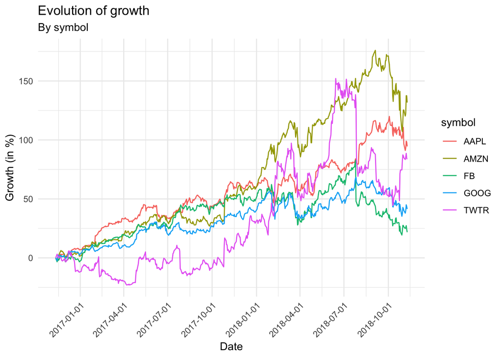

3. En filtrant les données initiales, affichez uniquement la valeur du cours (ajustée) de *Amazon* et *Google* du mois dernier.
4. Servez-vous de `geom_errorbar()` pour ajouter à votre graphe les valeurs minimales et maximales quotidiennes des cours d’*Amazon* et de *Google*.
5. Enfin, utilisez un theme fourni par le package `ggthemes` pour améliorer le rendu final. Un exemple du graphe attendu est donné ci-après.

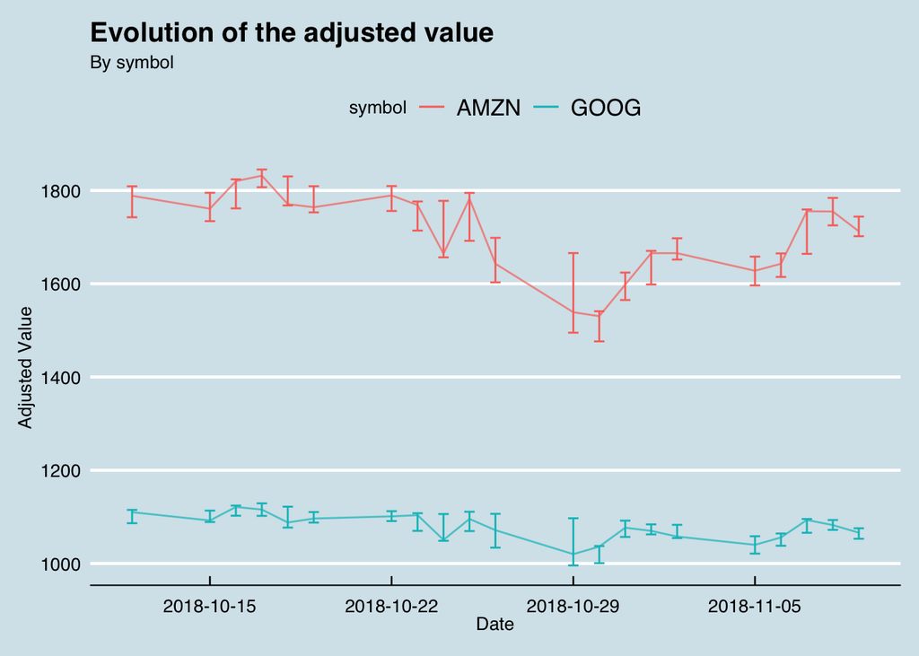

### Exercice 5 : (maps / cartes) *[facultatif]*

Les représentations graphiques cartographiées sont également très répandues. Elles permettent d’avoir un rendu très visuel sur la structure spatiale des variables que l’on analyse. Pensez par exemple aux résultats des élections présidentielles, à l’évolutoin des données climatiques, à la répartition de la richesse, etc. Dans cet exercice nous allons illustrer l’évolution démographique de la France par département, entre les années 2000 et 2010, comme illustré par la figure ci-après.

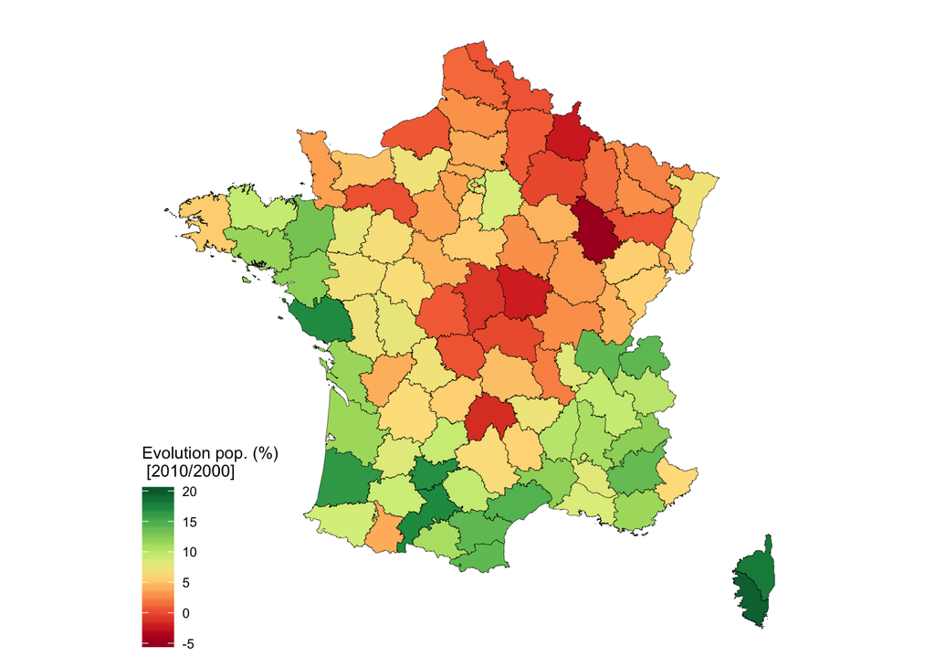

1. Il s’agit dans un premier temps, comme toujours, de récupérer les données que l’on cherche à analyser. Vous allez récupérer un fichier .csv répertoriant les données Françaises d’évolution démographique entre 1975 et 2010. Pour se faire, saisir la commande ci-après.

```r
# population france dataset
base <- read.csv("http://freakonometrics.free.fr/popfr19752010.csv", header = TRUE)
```

2. Regardez le contenu de ce jeu de données. Que pensez-vous faire pour représentez les données d’évolution par département ?
3. Pour arriver au jeu de données dans sa forme cible *(=1 donnée par variable par département)*, utilisez le code ci-après. Saisissez au-paravant le calcul de la variable `evol_ratio`.

```r
library(dplyr)
base <- base %>%
  # group data set by dep
  group_by(dep) %>%
  # compute sum of population by departement for 2010 and 2000
  summarise( pop2010 = sum(pop_2010), pop2000 = sum(pop_2000)) %>%
  # transform variables of the dataset
  mutate(evol_ratio = #TODO : compute evolution ratio from 2000 to 2010
           ,
         # print departement on 2 digits (1 -> 01)
         dep = sprintf("%02d", dep),
         # handle Corsica's departments
         dep = replace(dep,dep=="201","2A"),
         dep = replace(dep,dep=="202","2B"))
```

4. Pour tracer les contours de la carte, vous allez utiliser un fichier *shapefile* des départements français disponible sur le site data.gouv.fr. Téléchargez la version simplifiée en suivant [ce lien](http://osm13.openstreetmap.fr/~cquest/openfla/export/departements-20140306-100m-shp.zip).
5. Vous allez également avoir besoin des packages `ggmap`, `maptools` et `broom`. *Note : il existe des alternatives sous R, l’étudiant curieux pourra se faire son propre avis à l’utilisation de ces packages*.

```r
library(ggmap)
library(maptools)
library(broom)

# read shapefile, with "code_insee" as group variable.
map <- readShapeSpatial("my_path/departements-20140306-100m.shp", IDvar = "code_insee")
# make the dataset tidy regarding to the ggmap needs (= key-value structure)
map <- broom::tidy(map)
# reduce geographic envelope
map <- map %>% filter(long > -6 & long < 16 & lat > 40 & lat < 55)
```

6. Remplissez le code ci-après pour afficher votre première carte.

```r
# plot construction
ggplot() +
  # layer to draw data.
 geom_map(data = ...,
          aes(map_id = ...,
              fill = ...),
          color="black",
          size=0.1,
          map = ...) +
  # set default map projection
 coord_map() +
  # limit geographic envelope
 expand_limits(x = ..., y = ...) -> p

print(p)
```

7. Améliorez le rendu final en définissant votre échelle de couleur de remplissage. Vous pouvez par exemple utiliser la fonction `RColorBrewer::brewer.pal()` combinée à l’échelle de couleur `scale_fill_gradientn()` pour obtenir un gradient de couleur de votre choix.  
   N’oubliez pas de définir le titre de la légende.

```r
p <- p +
  scale_fill_gradientn(...)
print(p)
```

8. Enfin, utilisez le thème `theme_map()` de `ggthemes` optimisé pour l’affichage des cartes.

```r
library(ggthemes)
p <- p +
  theme_map()
print(p)
```

9. *[facultatif]* Retrouvez sur internet d’autres variables géographiques et utilisez pour générer votre propre carte. Bien souvent la difficulté réside uniquement dans la préparation du jeu de données au format attendu par `ggmap`. Vous pouvez aussi construire un dataframe aléatoirement pour tester.